# Optimizing sampling design for landscape genomics: Simulation summary results

Anusha P. Bishop, Drew E. Terasaki Hart, Ian J. Wang

# 1. Statistics over time

Stability in mean fitness and population size over time across different parameter levels demonstrate that the simulations are at equilibrium by then end.

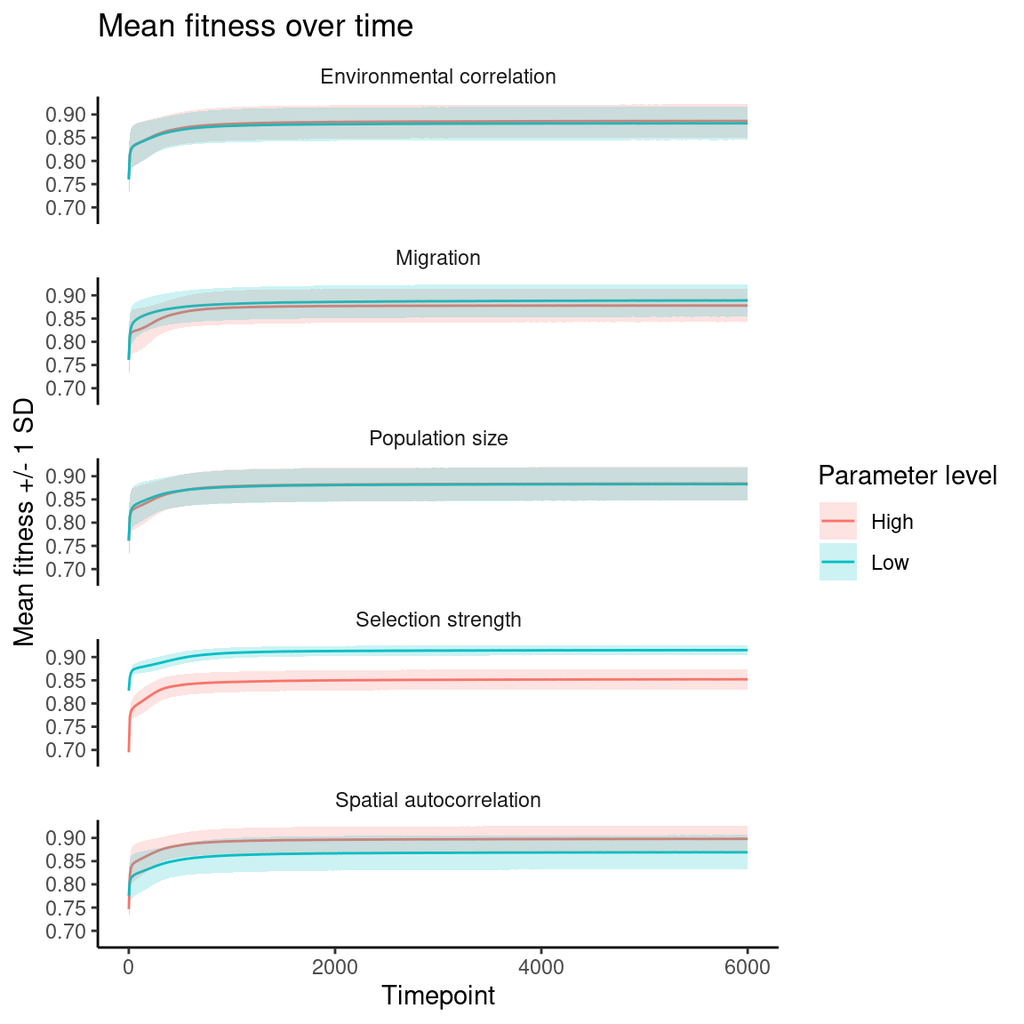

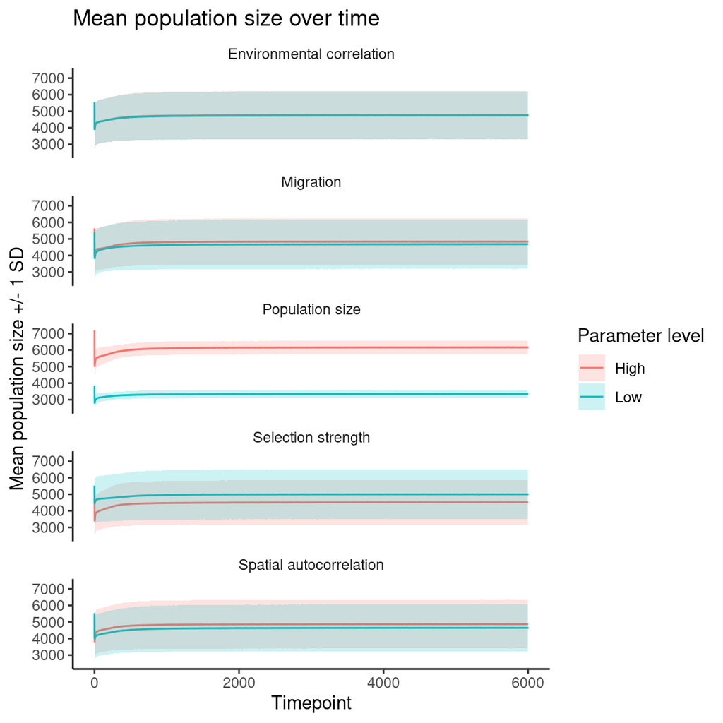

# 1. Population size

Summary of population sizes between our low (K = 1) and high (K = 2) population size scenarios:

```
## # A tibble: 2 × 3
##   mean_Nt min_Nt max_Nt
##     <dbl>  <dbl>  <dbl>
## 1   3352.   2796   3860
## 2   6154.   5307   6854
```

# 2. Phenotype-environment mismatch

Average phenotype-environment mismatch under low and high selection strength (phi):

```
## # A tibble: 2 × 2
##   phi   `Mean mismatch`
##   <fct>           <dbl>
## 1 0.5             0.174
## 2 1               0.154
```

Average phenotype-environment mismatch under low and high spatial autocorrelation (H):

```
## # A tibble: 2 × 2
##   H     `Mean mismatch`
##   <fct>           <dbl>
## 1 0.05            0.185
## 2 0.5             0.144
```

# 3. Phenotype-environment correlations

Phenotype-environment correlations are significant in 93% of simulations:

```
##       mean count
## 1 0.928125   891
```

Linear mixed effect model for phenotype-environment correlations:

Linear mixed effect model

IBE ~ population size + migration + selection strength + spatial autocorrelation + environmental correlation + (1 | seed)

| Predictors | Fixed Effects | Sum Sq | Mean Sq | NumDF | DenDF | F value | Pr(>F) |
| --- | --- | --- | --- | --- | --- | --- | --- |
| Population size | 0.0239 | 0.1376 | 0.1376 | 1 | 952.0000 | 17.81296 | 2.7 × 10<sup>−5</sup>* |
| Migration | −0.1237 | 3.6715 | 3.6715 | 1 | 952.0000 | 475.42684 | 8.2 × 10<sup>−86</sup>* |
| Selection strength | 0.0860 | 1.7739 | 1.7739 | 1 | 952.0000 | 229.69729 | 1.2 × 10<sup>−46</sup>* |
| Spatial autocorrelation | 0.4976 | 59.4347 | 59.4347 | 1 | 952.0000 | 7696.24584 | 0.0* |
| Environmental correlation | −0.1143 | 3.1346 | 3.1346 | 1 | 952.0000 | 405.90202 | 1.8 × 10<sup>−75</sup>* |

* p < 0.001

Mean and standard deviation of phenotype-environment correlations across low and high spatial autocorrelation (H):

```
## # A tibble: 2 × 3
##   H      mean     sd
##   <fct> <dbl>  <dbl>
## 1 0.05  0.358 0.180
## 2 0.5   0.855 0.0496
```

Mean and standard deviation of phenotype-environment correlations across low and high migration (m):

```
## # A tibble: 2 × 3
##   m      mean    sd
##   <fct> <dbl> <dbl>
## 1 0.25  0.668 0.239
## 2 1     0.544 0.307
```

# 4. Genotype-environment correlations

Genotype-environment correlations at adaptive loci are significant 63% of the time across all simulations and both environmental variables:

```
## # A tibble: 1 × 1
##    mean
##   <dbl>
## 1 0.630
```

Linear mixed effect model for genotype-environment correlations at adaptive loci with their corresponding environmental variable:

Linear mixed effect model

IBE ~ population size + migration + selection strength + spatial autocorrelation + environmental correlation + (1 | seed)

| Predictors | Fixed Effects | Sum Sq | Mean Sq | NumDF | DenDF | F value | Pr(>F) |
| --- | --- | --- | --- | --- | --- | --- | --- |
| Population size | 0.0215 | 0.8874 | 0.8874 | 1 | 7.6720K | 19.52437 | 1.0 × 10<sup>−5</sup>* |
| Migration | −0.0447 | 3.8323 | 3.8323 | 1 | 7.6720K | 84.31351 | 5.3 × 10<sup>−20</sup>* |
| Selection strength | 0.0411 | 3.2472 | 3.2472 | 1 | 7.6720K | 71.44014 | 3.4 × 10<sup>−17</sup>* |
| Spatial autocorrelation | 0.2861 | 157.1108 | 157.1108 | 1 | 7.6720K | 3456.55331 | 0.0* |
| Environmental correlation | −0.0512 | 5.0415 | 5.0415 | 1 | 7.6720K | 110.91681 | 9.2 × 10<sup>−26</sup>* |

* p < 0.001

Mean and standard deviation of genotype-environment correlations across low and high spatial autocorrelation (H):

```
## # A tibble: 4 × 4
## # Groups:   adaptive [2]
##   adaptive H       mean     sd
##   <lgl>    <fct>  <dbl>  <dbl>
## 1 FALSE    0.05  0.0644 0.0290
## 2 FALSE    0.5   0.121  0.0434
## 3 TRUE     0.05  0.0913 0.0503
## 4 TRUE     0.5   0.320  0.0374
```

Mean and standard deviation of genotype-environment correlations across low and high migration (m):

```
## # A tibble: 4 × 4
## # Groups:   adaptive [2]
##   adaptive m       mean     sd
##   <lgl>    <fct>  <dbl>  <dbl>
## 1 FALSE    0.25  0.126  0.0417
## 2 FALSE    1     0.0603 0.0213
## 3 TRUE     0.25  0.236  0.116
## 4 TRUE     1     0.176  0.128
```

Linear mixed effect model of the proportion of times the neutral loci have a greater correlation with the environment than the adaptive loci (an estimate of the confounding effect of neutral structure):

Linear mixed effect model

proportion ~ population size + migration + selection strength + spatial autocorrelation + environmental correlation + (1 | seed)

| Predictors | Fixed Effects | Sum Sq | Mean Sq | NumDF | DenDF | F value | Pr(>F) |
| --- | --- | --- | --- | --- | --- | --- | --- |
| Population size | −0.0777 | 1.4497 | 1.4497 | 1 | 952.0000 | 101.7835 | 8.3 × 10<sup>−23</sup>* |
| Migration | 0.1893 | 8.6012 | 8.6012 | 1 | 952.0000 | 603.8742 | 1.2 × 10<sup>−103</sup>* |
| Selection strength | −0.1107 | 2.9387 | 2.9387 | 1 | 952.0000 | 206.3217 | 1.7 × 10<sup>−42</sup>* |
| Spatial autocorrelation | −0.3039 | 22.1632 | 22.1632 | 1 | 952.0000 | 1556.0303 | 1.8 × 10<sup>−202</sup>* |
| Environmental correlation | 0.0984 | 2.3235 | 2.3235 | 1 | 952.0000 | 163.1276 | 1.4 × 10<sup>−34</sup>* |

* p < 0.001

Mean and standard deviation of the proportion across low and high spatial autocorrelation (H):

```
## # A tibble: 2 × 3
##   H      mean    sd
##   <fct> <dbl> <dbl>
## 1 0.05  0.566 0.212
## 2 0.5   0.262 0.128
```

Mean and standard deviation of the proportion across low and high migration (m):

```
## # A tibble: 2 × 3
##   m      mean    sd
##   <fct> <dbl> <dbl>
## 1 0.25  0.319 0.161
## 2 1     0.509 0.252
```